# Two-way ANOVA test based on the STAR Experiment

chenrui_lu

2023-02-08

# **Abstract**

# **Introduction**

Our project uses mainly the dataset from the Tennessee Student Teacher Achievement Ratio (STAR), conducted between 1985 and 1989 based on early childhood education theory, which was a large-scale, randomized, longitudinal experiment. The STAR project examined the effects of different class types on children’s academic performance by collecting children’s academic performance over four consecutive years, beginning in kindergarten.

The study randomly assigned students to small classes, regular classes, and regular classes with a full-time aide. Class placement remained constant throughout the school year, with no interventions other than class types and the provision of a full-time aide to the class. The large sample and random assignment also provide some assurance of data validity.

In this project, we only examine whether there are significant differences in math scores across class types in first grade and if so, we examine which types of classes are associated with the highest math scores. In particular, we also treat each teacher as the basic unit of analysis, i.e., we will consider each class (uniquely labeled by a specific teacher) as an observation.

This study has some positive implications for both the social and educational domains. By controlling for class size, it can further improve student academic performance. This not only allows low-income students to achieve the same academic performance while spending less on tuition; it also brings new momentum to the education industry as a whole and provides a solid foundation for students to continue learning throughout their lives.

# **Background**

In the STAR project, all Tennessee schools offering K-3 were invited to participate, which ensured the diversity of the sample. Also, each participating school had sufficient student populations to offer small classes (15-17 students), regular classes (22-25 students), and regular classes with a full-time aide (22-25 students) to make the experiment run smoothly. A total of 79 schools met the requirements, providing nearly 7,000 students per grade, indicating further credibility for this experiment, as the large sample also provides some assurance of the inevitable student mobility. For the STAR sampling mechanism, students and teachers were randomly assigned to one of the three class types. Random sampling ensures that student achievement is only affected by class size and that there is no assignment of individual outstanding students or teachers to specific groups.

For this study, which is concerned with whether there are significant differences in math scores across class sizes in first grade, the target population for this experiment was first-grade students in Tennessee. And four variables, g1tchid, g1schid, g1classtype and g1mathss, were selected for the two-way ANOVA experiment.

# **Descriptive analysis**

**Data pre-processing and variables selection**

First, we have to deal with the missing values, after extracting the four variables g1tchid, g1schid, g1classtype and g1mathss, we test the number of NA for the new data and find that the data are all missing as 4772, missing one as 231, and no missing as 6598, which means that the missing one value accounts for a relatively small amount in the data set. Therefore, we can remove all the rows containing missing values to get 6598 observations. Next, we obtain math scaled scores in the 1st grade with teachers based on a group by ‘teacherid’ and averaging the scores of each group math as the unit.

**Descriptive statistics for the outcome with key variables**

From the dataset, we can see that each teacher was assigned a various number of students, and we integrated the students’ math scores, and the table below shows the summary measure for each teacher.

```
## # A tibble: 339 × 6
##    `data$tchid`   min   max  mean quantile0.25 quantile0.75
##           <dbl> <dbl> <dbl> <dbl>        <dbl>        <dbl>
##  1     11203804   446   532  487.         472          510.
##  2     11203805   444   553  500.         488          518
##  3     11203806   449   562  496.         476.         522.
##  4     12305604   451   612  524.         495          538
##  5     12305605   488   584  533.         515          562
##  6     12305606   493   572  534.         523          549
##  7     12807604   507   612  555.         526          575.
##  8     12807605   444   545  503.         476.         528.
##  9     12807606   474   627  544.         529          555
## 10     12807607   446   567  510.         495          535
## # … with 329 more rows
```

```
##        classtype=1,n=1867 classtype=2,n=2507 classtype=3,n=2224
## Min             425.00000          408.00000          404.00000
## Max             676.00000          676.00000          676.00000
## mean            538.67006          525.27443          529.61466
## median          535.00000          523.00000          529.00000
## sd               44.11365           41.65123           42.87276
```

Also, the relationship between school and math scores can be shown in a bar chart.

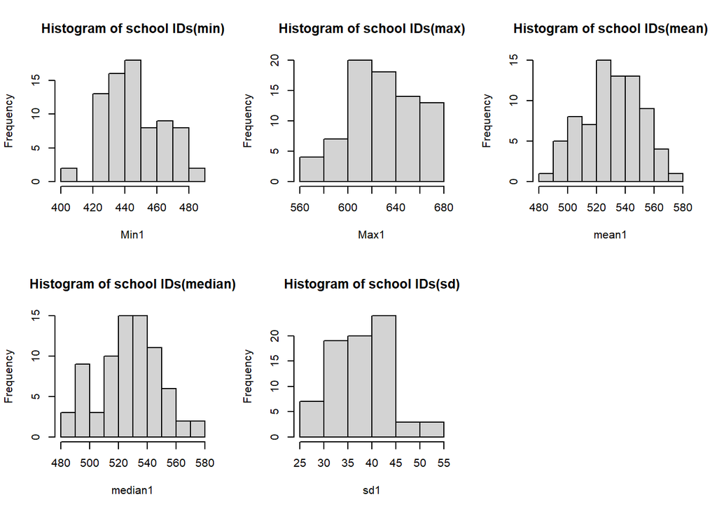

To better show the relationship between school indicators, class types, and math scaled scores in 1st grade. we use ggplot to plot math outcome v.s. class type and math outcome v.s. class type.

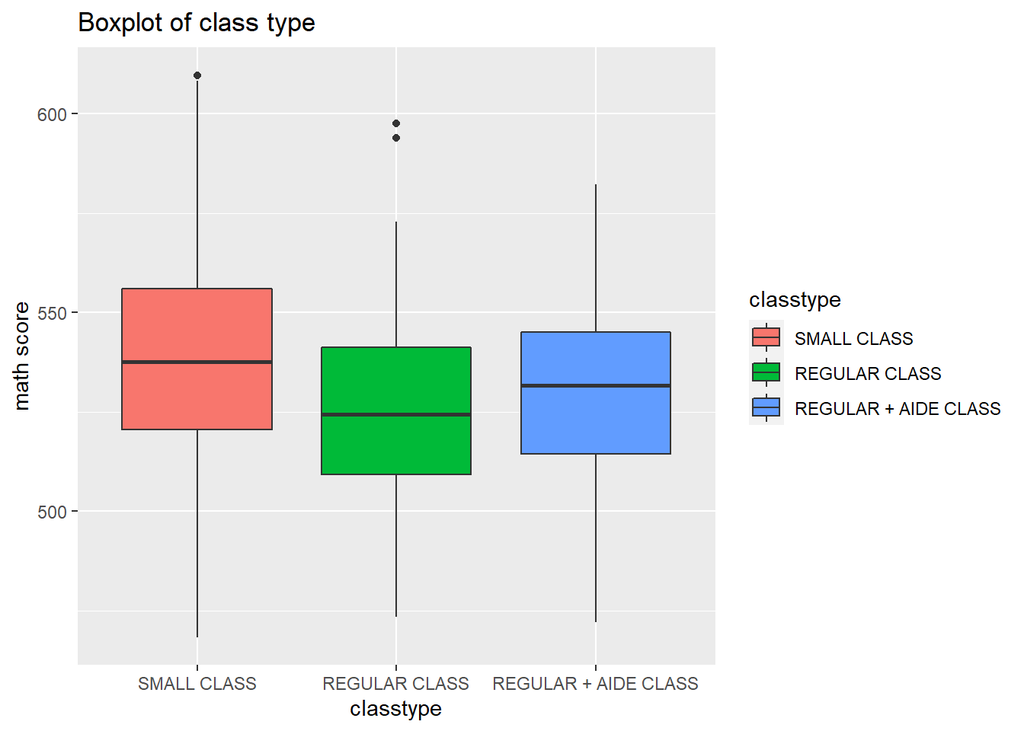

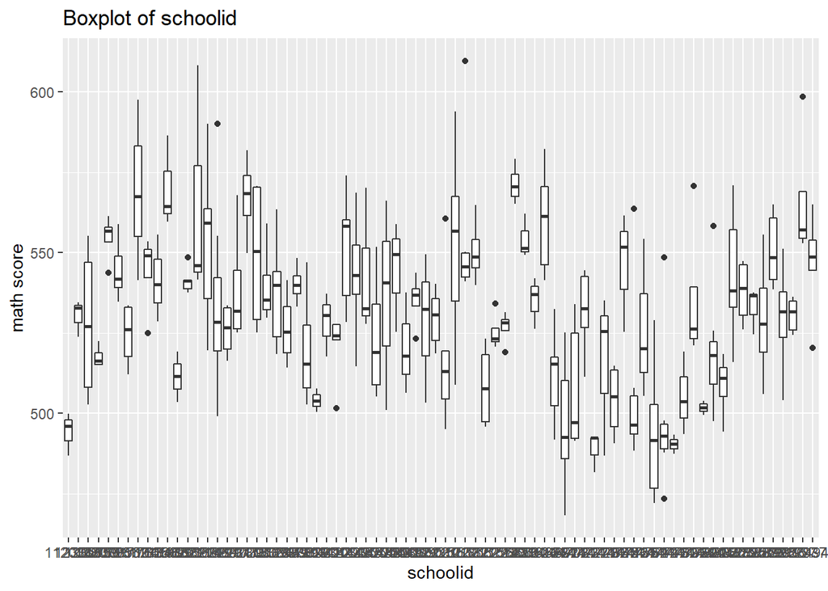

# **Inferential analysis**

For this experiment, we use the Two-way ANOVA model to investigate whether different class sizes have an effect on student performance in mathematics. We consider a dataset of a first-grade student, from 76 schools with three different class sizes: small, regular, and regular with an aide.

In practice, we use the factor effect form: $Y_{ijk}=\mu_{ijk}+\epsilon_{ijk}=\mu_{..}+\alpha_i+\beta_j+(\alpha\beta)_{ij}+\epsilon_{ijk}$,

where {$\epsilon_{ijk}$} are i.i.d. $N(0,\sigma^2)$, k=1,…,n, j=1,…,76, i=1,2,3

And the index i represents the class type: small (i=1), regular (i=2), regular with an aide (i=3), and the index j represents the school indicator.

The factor effects are still defined as follows

$\mu_{..}=\Sigma_{i=1}^a\Sigma_{j=1}^b\mu_{ij}/(ab)$, $\mu_{i⋅}=\Sigma_{j=1}^b\mu_{ij}/b$,$\mu_{⋅j}=\Sigma_{i=1}^a\mu_{ij}/a$.

Furthermore, we have $\alpha_i=\mu_{i⋅}−\mu{⋅⋅},\beta_j=\mu_{⋅j}-\mu_{⋅⋅}$, $(\alpha\beta)_{ij}=\mu_{ij}−\mu_{i.}−\mu_{.j}+\mu_{..}$

And estimators follow the same form by plugging the sample means in the equations above.

And for this model, the constraints are as follows:

$\sum_{i=1}^3\alpha_i = \sum_{j=1}^{76}\beta_j=0$

$\sum_{i=1}^3(\alpha\beta)_{ij}=\sum^{76}_{j=1}(\alpha\beta)_{ij}=0$

The assumptions for this model are as follows:

1. the error terms are homogeneity

2. the error terms are normality

3. the error terms are independence

4. there are no outliers that may impact normality and homogeneity of variance.

And these assumptions can be verified by the residual plot of the fitted model, Levene’s test, etc. The specific results will be shown in the sensitivity analysis.

After turning the school indicator as a factor, we use aov() to do the ANOVA analysis. We also include a cross-term to compare whether class types and schools have an interaction effect on first graders’ math achievement, and the two ANOVA tests’ results are as follows.

```
##              Df Sum Sq Mean Sq F value   Pr(>F)
## classtype     2  11617    5809  20.991 3.52e-09 ***
## schid        75 136833    1824   6.593  < 2e-16 ***
## Residuals   261  72225     277
## ---
## Signif. codes:  0 '***' 0.001 '**' 0.01 '*' 0.05 '.' 0.1 ' ' 1
```

```
##                  Df Sum Sq Mean Sq F value   Pr(>F)
## classtype         2  11617    5809  19.936 3.69e-08 ***
## schid            75 136833    1824   6.262  < 2e-16 ***
## classtype:schid 146  38718     265   0.910    0.706
## Residuals       115  33507     291
## ---
## Signif. codes:  0 '***' 0.001 '**' 0.01 '*' 0.05 '.' 0.1 ' ' 1
```

Compared with two ANOVA test results, it can be found that under 0.95 confidence level, the interaction term could be dropped. Therefore, the model can be changed to

$Y_{ijk}=\mu_{ijk}+\epsilon_{ijk}=\mu_{..}+\alpha_i+\beta_j+\epsilon_{ijk}$

Besides, the estimated coefficients for school IDs are between -9.230365 and 77.883336, which means the school influence the math score significantly. This conclusion also can be concluded by the ANOVA test result, which shows that the P-value for the schid variable is <2e-16. So under 0.95 confidence level, we can reject the null hypothesis that the school can not be dropped from the model.

And the main effect of classtype plot as below.

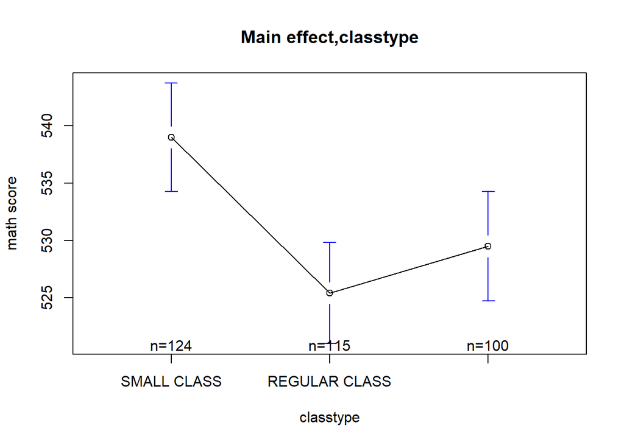

When we conclude that the class type has a significant impact on student’s math performance, to address the second question, which class type is most effective in improving academic performance, we use the Tukey test to figure out the differences in mean levels of three class types under 0.95 confidence level. According to the results in the following figure, small-class math performance is outstanding among three types of class sizes, which also means that small class sizes are the most effective way to improve academic performance.

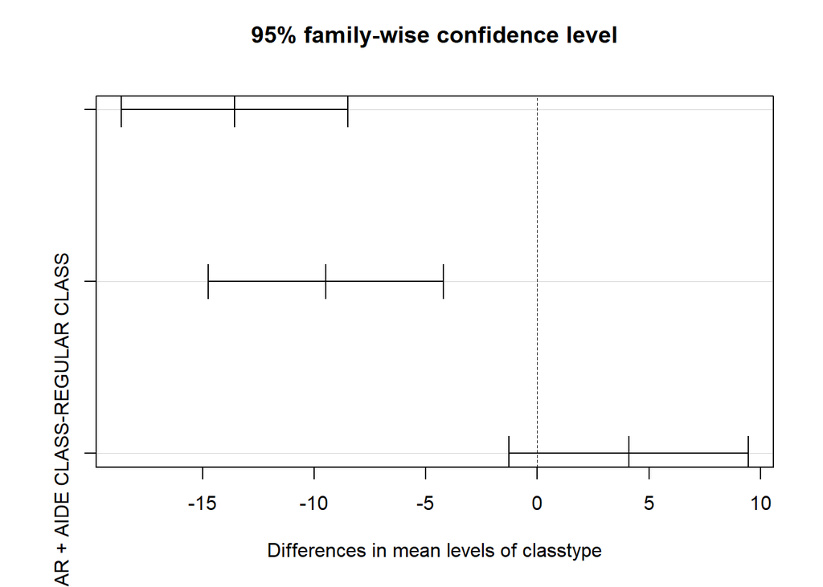

# **Sensitive analysis**

## Diagnostics

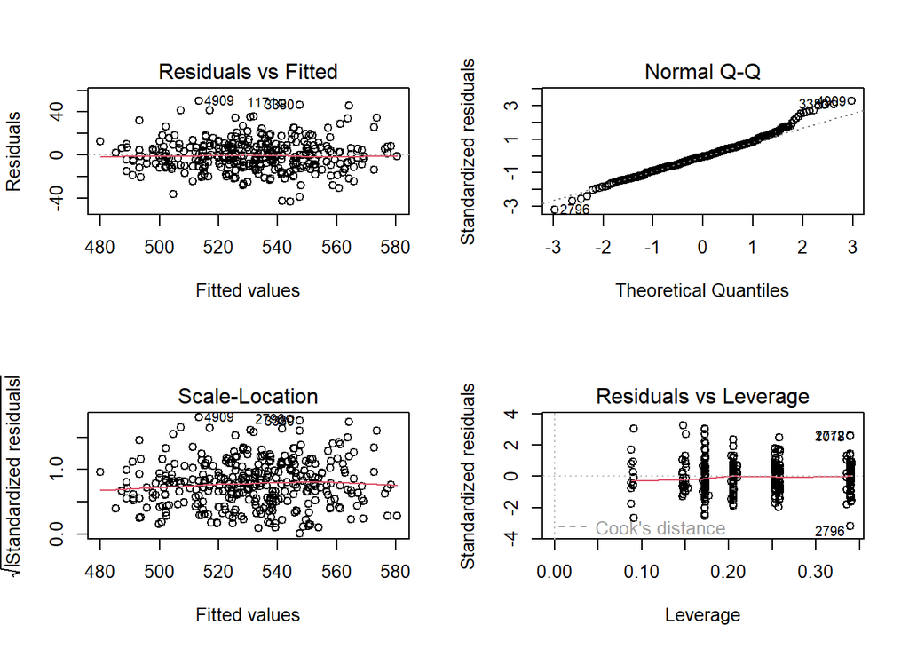

```
##              Df Sum Sq Mean Sq F value Pr(>F)
## classtype     2    495   247.5   2.979 0.0526 .
## schid        75   8663   115.5   1.390 0.0314 *
## Residuals   261  21688    83.1
## ---
## Signif. codes:  0 '***' 0.001 '**' 0.01 '*' 0.05 '.' 0.1 ' ' 1
```

## Alternative methods

**Other summary measures**

To prove the validity of the model, instead of using the mean, we can also use the median scores of every class as “class quality”, and the ANOVA test’s result is as follows. We can find that classtype still has a significant impact on math scores, and the test also does not need the interaction of classtype and school. Besides, the small class has the highest math score among those of other class sizes.

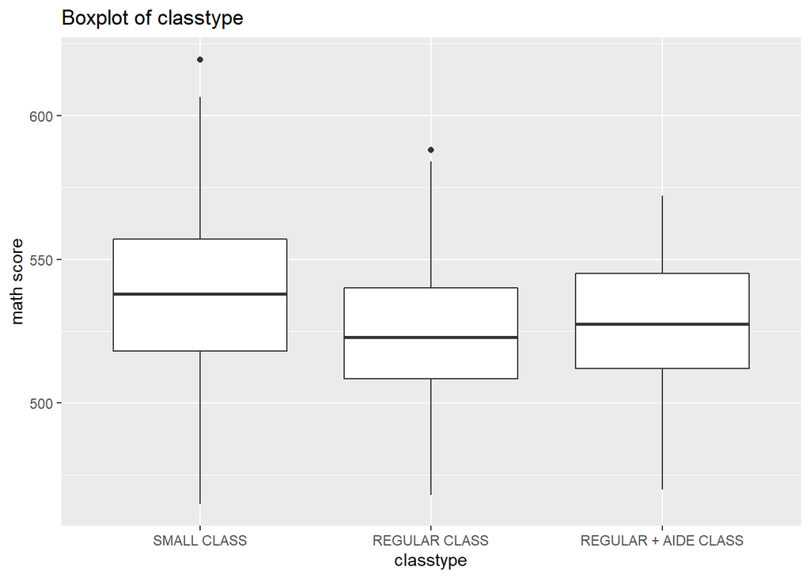

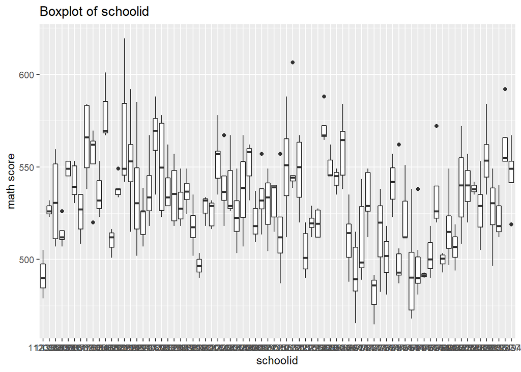

```
##                  Df Sum Sq Mean Sq F value   Pr(>F)
## classtype         2  11014    5507  18.266 1.29e-07 ***
## schid            75 149370    1992   6.606  < 2e-16 ***
## classtype:schid 146  46682     320   1.061    0.373
## Residuals       115  34672     301
## ---
## Signif. codes:  0 '***' 0.001 '**' 0.01 '*' 0.05 '.' 0.1 ' ' 1
```

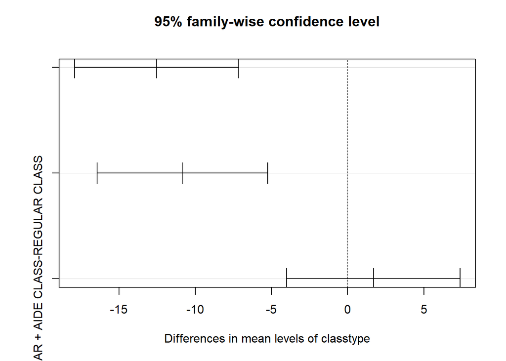

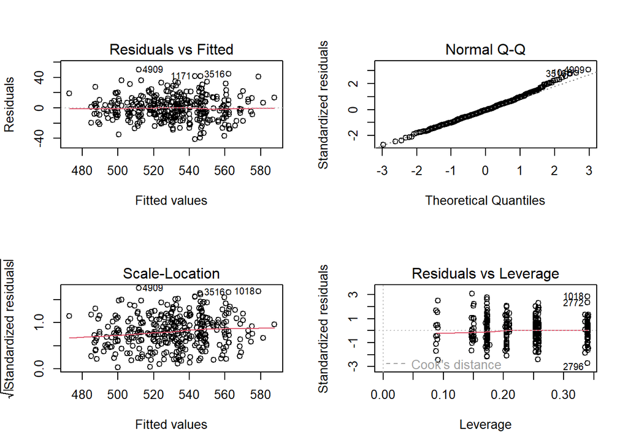

```
##              Df Sum Sq Mean Sq F value  Pr(>F)
## classtype     2    766   382.9   4.717 0.00972 **
## schid        75   9334   124.5   1.533 0.00770 **
## Residuals   261  21190    81.2
## ---
## Signif. codes:  0 '***' 0.001 '**' 0.01 '*' 0.05 '.' 0.1 ' ' 1
```

**Nonparametric approach**

To further verify the validity of the model, we used a nonparametric approach to rank the math scores and used the ANOVA test again, and the results are shown in the table below. It can be seen that both classtype and school have some effect on teaching, and there is a larger gap between the math score of small classes and those of other class types.

```
##               Df    Sum Sq   Mean Sq F value Pr(>F)
## classtype      2 3.546e+08 177286938   63.14 <2e-16 ***
## schid         75 5.261e+09  70146546   24.98 <2e-16 ***
## Residuals   6520 1.831e+10   2807753
## ---
## Signif. codes:  0 '***' 0.001 '**' 0.01 '*' 0.05 '.' 0.1 ' ' 1
```

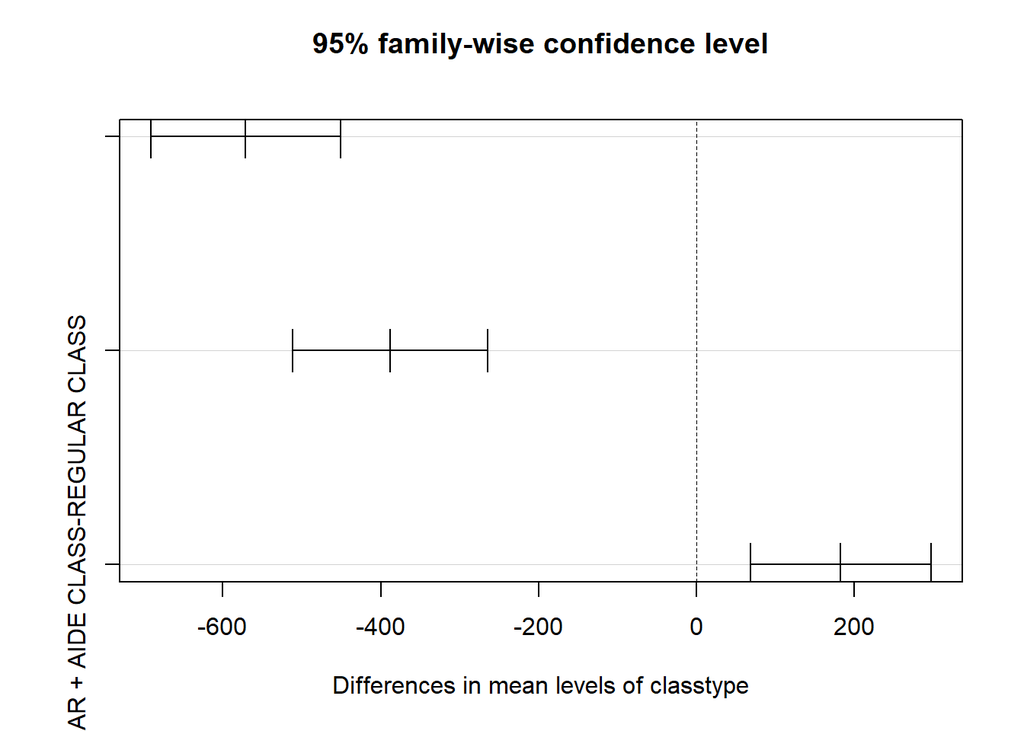

# **Disucussion**

For our project, we aim to find whether there are significant differences in math scaled scores in 1st grade across class types; and if so, which type of classes receive the highest scores on the math test. After using various methods to preprocess the data, two-way ANOVA test, and diagnostic, we conclude that there are significant differences in math scaled scores in 1st grade across class types, and the small class receives the highest scores on the math test.

Based on this experiment, we found that small class size had a significant effect on student performance in mathematics and that even the academic performance of a regular class with the addition of a full-time teaching assistant did not compare to the academic performance of students in a small class without a full-time aide. Therefore, the most effective instruction can be achieved by using redundant full-time teaching assistants as small classroom teachers and keeping the first-grade class size to about 15 students.

Moreover, controlling class size does not mean an absolute increase in student performance. While controlling class size, teachers and staff should also make corresponding changes in instructional planning. For example, students can start small classes early and keep the small class environment for a longer period, among other methods.

# Reference

1.Achilles, C. M. (2012, September 30). Class-size policy: The Star Experiment and related class-size studies. NCPEA policy brief. volume 1, Number

2. NCPEA Publications. Retrieved February 17, 2023, from https://eric.ed.gov/?id=ED540485 2.jnwei21. (n.d.). JNWEI21/STA207-project1. GitHub. Retrieved February 17, 2023, from https://github.com/jnwei21/STA207-project1